# Final Project - Poverty and Race Inequalities in the US

Lehmann Jacob - Sanchez Luis - Minh-Tri Ho - Minh-Tuan Ho

May 2, 2017

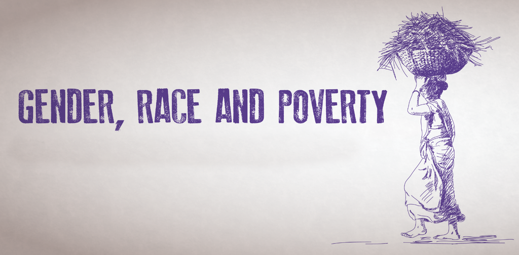

# **Introduction**

This is our R Notebook, for the Final Project of the course CS329e Elements of Data Visualization. This notebook includes every step that we took to build our project. In this project, we are going to look at the Poverty and Race Inequalities during the last Census Data, mainly looking at Wealth, per gender, per race, and per state, as well as Health Insurance. We often talk about race inequality in the United States, but it has always been hard to properly separate facts from cliches. In this project, we wanted to take a close look into those wealth disparities, and because we understand that the country is quite vast, we broke it down to the state level, giving us more insight into those inequalities throughout the country.

# **The Data**

# **R Configuration**

**In order to start, we must install the following packages:** ggplot2, dplyr, tidyr, shiny, shinydashboard, data.world, readr, DT, leaflet, plotly, lubridate, reshape2, geojson, geojsonio

# **Subset and Summary**

## *Head*

```r
head(IncomeAbove200k)
```

```
##   StateName StateABV WhiteAbove200 BlackAbove200 HispanicLatinoAbove200
## 1   Alabama       AL         45236          3063                    949
## 2    Alaska       AK         13279           282                    489
## 3   Georgia       GA        127022         14531                   4222
## 4    Hawaii       HI         10938           249                   1102
## 5     Idaho       ID         14552            56                    542
## 6  Illinois       IL        241916         10958                  10475
```

```r
head(PovertyUSAStates)
```

```
##   StateABV    StateName PopulationPolled PopulationBelowPovertyLVL
## 1       CA   California         37678735                   6135142
## 2       TX        Texas         25923852                   4472451
## 3       FL      Florida         19228208                   3180109
## 4       NY     New York         19164034                   3005943
## 5       IL     Illinois         12571110                   1801118
## 6       PA Pennsylvania         12365782                   1666569
##   WhitePopulation BlackPopulation LatinoHispanic
## 1        23332028         2165064       14494492
## 2        19462386         3014154       10005754
## 3        14666794         3050172        4592774
## 4        12388352         2960574        3541633
## 5         9118539         1768093        2090162
## 6        10137380         1319503         783216
##   WhitePopulationBelowPovertyLVL BlackPopulationBelowPovertyLVL
## 1                        3428428                         534827
## 2                        3090465                         710752
## 3                        2049223                         838187
## 4                        1404979                         691900
## 5                         963036                         538580
## 6                        1062555                         381842
##   LatinoHispanicBelowPovertyLVL
## 1                       3294059
## 2                       2524283
## 3                        991264
## 4                        917179
## 5                        429853
## 6                        251215
```

```r
head(USAHealthInsurance)
```

```
##   StateABV StateName MalePopulationNoHI FemalePopulationNoHI
## 1       AL   Alabama             313448               287711
## 2       AK    Alaska              70923                58041
## 3       GA   Georgia             866461               813554
## 4       HI    Hawaii              44986                35235
## 5       ID     Idaho             122028               112766
## 6       IL  Illinois             781758               616877
```

## *Summary*

```r
summary(IncomeAbove200k)
```

```
##       StateName     StateABV  WhiteAbove200    BlackAbove200
##  Alabama   : 1   AK     : 1   Min.   :  6892   Min.   :    1.0
##  Alaska    : 1   AL     : 1   1st Qu.: 20275   1st Qu.:  325.5
##  Arizona   : 1   AR     : 1   Median : 46395   Median : 1553.5
##  Arkansas  : 1   AZ     : 1   Mean   :100121   Mean   : 4628.1
##  California: 1   CA     : 1   3rd Qu.:121851   3rd Qu.: 4602.0
##  Colorado  : 1   CO     : 1   Max.   :742500   Max.   :27949.0
##  (Other)   :46   (Other):46
##  HispanicLatinoAbove200
##  Min.   :  130.0
##  1st Qu.:  588.2
##  Median : 1430.5
##  Mean   : 6253.1
##  3rd Qu.: 4499.5
##  Max.   :83880.0
##
```

```r
summary(PovertyUSAStates)
```

```
##     StateABV       StateName  PopulationPolled   PopulationBelowPovertyLVL
##  AK     : 1   Alabama   : 1   Min.   :  565647   Min.   :  64995
##  AL     : 1   Alaska    : 1   1st Qu.: 1744447   1st Qu.: 241662
##  AR     : 1   Arizona   : 1   Median : 4062986   Median : 644246
##  AZ     : 1   Arkansas  : 1   Mean   : 6003259   Mean   : 949330
##  CA     : 1   California: 1   3rd Qu.: 6579361   3rd Qu.:1012931
##  CO     : 1   Colorado  : 1   Max.   :37678735   Max.   :6135142
##  (Other):46   (Other)   :46
##  WhitePopulation    BlackPopulation   LatinoHispanic
##  Min.   :  243341   Min.   :   4383   Min.   :    9602
##  1st Qu.: 1487298   1st Qu.:  62074   1st Qu.:  137123
##  Median : 2985653   Median : 300800   Median :  335323
##  Mean   : 4427251   Mean   : 740912   Mean   : 1089513
##  3rd Qu.: 5346521   3rd Qu.:1277656   3rd Qu.:  792194
##  Max.   :23332028   Max.   :3050172   Max.   :14494492
##
##  WhitePopulationBelowPovertyLVL BlackPopulationBelowPovertyLVL
##  Min.   :  18700                Min.   :  1057
##  1st Qu.: 201641                1st Qu.: 17203
##  Median : 386039                Median : 90692
##  Mean   : 577332                Mean   :201100
##  3rd Qu.: 694350                3rd Qu.:368741
##  Max.   :3428428                Max.   :838187
##
##  LatinoHispanicBelowPovertyLVL
##  Min.   :   1441
##  1st Qu.:  36827
##  Median :  87236
##  Mean   : 279202
##  3rd Qu.: 212948
##  Max.   :3294059
##
```

```r
summary(USAHealthInsurance)
```

```
##     StateABV       StateName  MalePopulationNoHI FemalePopulationNoHI
##  AK     : 1   Alabama   : 1   Min.   :  22058    Min.   :  14100
##  AL     : 1   Alaska    : 1   1st Qu.: 106732    1st Qu.:  91226
##  AR     : 1   Arizona   : 1   Median : 258783    Median : 221146
##  AZ     : 1   Arkansas  : 1   Mean   : 420691    Mean   : 361669
##  CA     : 1   California: 1   3rd Qu.: 458208    3rd Qu.: 399150
##  CO     : 1   Colorado  : 1   Max.   :3038520    Max.   :2616531
##  (Other):46   (Other)   :46
```

## *Subset*

```r
subset(IncomeAbove200k)
```

```
##               StateName StateABV WhiteAbove200 BlackAbove200
## 1               Alabama       AL         45236          3063
## 2                Alaska       AK         13279           282
## 3               Georgia       GA        127022         14531
## 4                Hawaii       HI         10938           249
## 5                 Idaho       ID         14552            56
## 6              Illinois       IL        241916         10958
## 7               Indiana       IN         64699          2160
## 8                  Iowa       IA         37734           340
## 9                Kansas       KS         38728           588
## 10             Kentucky       KY         41786          1377
## 11            Louisiana       LA         53240          4415
## 12                Maine       ME         16349            85
## 13              Arizona       AZ         82186          1642
## 14             Maryland       MD        151010         27949
```

[output cut: 91 more lines]

```r
subset(PovertyUSAStates)
```

```
##    StateABV            StateName PopulationPolled
## 1        CA           California         37678735
## 2        TX                Texas         25923852
## 3        FL              Florida         19228208
## 4        NY             New York         19164034
## 5        IL             Illinois         12571110
## 6        PA         Pennsylvania         12365782
## 7        OH                 Ohio         11258461
## 8        GA              Georgia          9737146
## 9        MI             Michigan          9678203
## 10       NC       North Carolina          9592619
## 11       NJ           New Jersey          8728868
## 12       VA             Virginia          8008050
## 13       WA           Washington          6850693
## 14       AZ              Arizona          6488917
```

[output cut: 197 more lines]

```r
subset(USAHealthInsurance)
```

```
##    StateABV            StateName MalePopulationNoHI FemalePopulationNoHI
## 1        AL              Alabama             313448               287711
## 2        AK               Alaska              70923                58041
## 3        GA              Georgia             866461               813554
## 4        HI               Hawaii              44986                35235
## 5        ID                Idaho             122028               112766
## 6        IL             Illinois             781758               616877
## 7        IN              Indiana             435478               392864
## 8        IA                 Iowa             123063                99638
## 9        KS               Kansas             167371               150748
## 10       KY             Kentucky             260999               229263
## 11       LA            Louisiana             358049               341703
## 12       ME                Maine              73835                58195
## 13       AZ              Arizona             531541               450843
## 14       MD             Maryland             290633               232439
```

[output cut: 38 more lines]

# **Extract-Translate-Load (ETL)**

We have 3 similar ETL, one for each dataset, we are going to reproduce one here to allow you to do it on you own at your convenience.

```r
require(readr)
#require(plyr)

## Set the Working Directory to the 02 Shiny
file_path = "../01 Data/PreETL_IncomeAbove200.csv"
df <- readr::read_csv(file_path)

## Columns with numerical values
measures <- c("WhiteAbove200","BlackAbove200","HispanicLatinoAbove200")

## Categorical Columns
dimensions <- setdiff(names(df), measures)

## Get rid of special characters in each column.
for(n in names(df)) {
  df[n] <- data.frame(lapply(df[n], gsub, pattern="[^ -~]",replacement= ""))
}

## Make state abbreviations all upper case.
df["StateABV"] <- data.frame(lapply(df["StateABV"], toupper))

## create a function that replaces NA with empty strings
na2emptyString <- function (x) {
  x[is.na(x)] <- ""
  return(x)
}

## Replace special characters using regular expressions
if( length(dimensions) > 0) {
  for(d in dimensions) {
    ## Change NA to the empty string.
    df[d] <- data.frame(lapply(df[d], na2emptyString))
    ## Get rid of " and ' in dimensions (quotation marks).
    df[d] <- data.frame(lapply(df[d], gsub, pattern="[\"']",replacement= ""))
    ## Change & to " and " in dimensions.
    df[d] <- data.frame(lapply(df[d], gsub, pattern="&",replacement= " and "))
    ## Change : to ; in dimensions.
    df[d] <- data.frame(lapply(df[d], gsub, pattern=":",replacement= ";"))
  }
}

## create a function replacing NA to zero
na2zero <- function (x) {
  x[is.na(x)] <- 0
  return(x)
}
## Get rid of all characters in measures except for numbers, the - sign, and period. Change NA to 0.
if( length(measures) > 1) {
  for(m in measures) {
    print(m)
    df[m] <- data.frame(lapply(df[m], gsub, pattern="[^--.0-9]",replacement= ""))
    df[m] <- data.frame(lapply(df[m], na2zero))
    df[m] <- data.frame(lapply(df[m], function(x) as.numeric(as.character(x)))) # This is needed to turn measures back to numeric because gsub turns them into strings.
  }
}

write.csv(df, gsub("Pre_", "", file_path), row.names=FALSE, na = "")
```

# **Data Visualization #1: Tableau - United States Map colored by Poverty**

## *Description*

In this first graph, we want to have a visual look of poverty in the United States per state. The map therefore represents the 52 US States, the color gradient spanning from Blue to Yellow, representing the percentage of people below the poverty level. The ratio more specifically represents the ratio of population in poverty divided by the state population.

## *Graph*

[figure not shown]

## *Interpretation*

We can see that the northern states have relatively less poor people as a percentage of the population compared to the southern states which have relatively more. Few exceptions such as Michigan or Oregon in the North, but the trend stays quite valid for most states.

# **Data Visualization #2: Tableau - Poverty per Race**

## *Description*

Now that we have seen how Poverty looked like per state, we want to take a deeper look into the states for a comparison between races. For that, we built a Barchart of Poverty broken down by state and by race. The blue bars represent the black people, the red bars represent the hispanic people, and the green bars represent the white people living in poverty.

## *Graph*

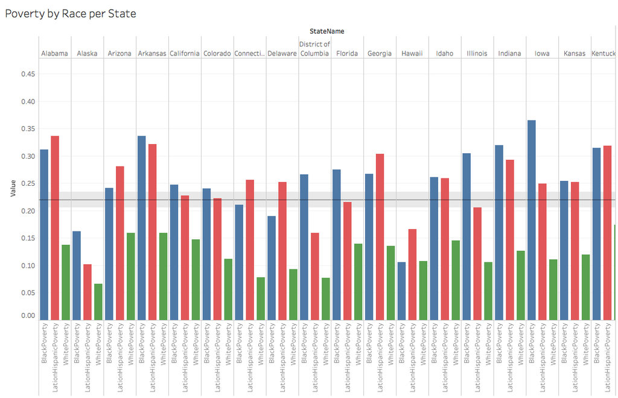

## *Interpretation*

It is quite apparent that consistently throughout the states, while people represent a lower percentage of the population living in poverty, whereas black and hispanic people have relatively the same high percentage of people living in poverty. When taking the average of 22 percent, we can observe that white people are consistently and significantly below that average, whereas black and hispanic are mostly above. There are however a few states which were able to decrease those inequalities, such as Alaska and Hawaii, and in a lesser measure the District of Columbia for Hispanic people.

# **Data Visualization #3: Tableau - Poverty versus Health Insurance by State and Gender**

## *Description*

The third visualization is a plot that displays not having health insurance where one blue is male and red is female, as well as a linear regression per gender. That visualization implicitly measures the quality of Social Services to provide basic healthcare to poor people.

## *Graph*

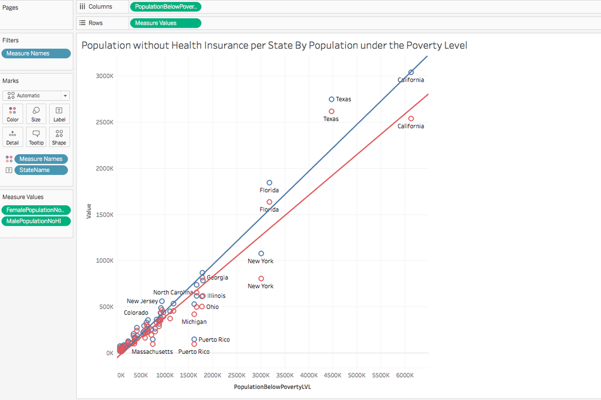

## *Interpretation*

Because of the size of some of the States, it makes sense to have California and Texas having a relatively high number of people below the poverty level, but compared to the number of people without health insurance, we can see that California follow the national average, whereas Texas or Florida have a higher rate of people without health insurance. On the other hand, states such as New York, Ohio, Michigan, Puerto Rico or Massachusetts have a really low rate of people without health insurance. At the same time, the absolute value of people still matter as it is understandable to have more trouble enforcing basic healthcare to poor people in bigger states.

# **Data Visualization #4: Tableau - Wealthy People by Race and by State**

## *Description*

Finally, we want to contrast the picture that we have painted so far with the number of wealthy people, broken down by race. The last visualization is a scatter plot of the number of extremely rich people, which we categorized by the number of people who have a revenue that is above 200000$. We have black people in blue, hispanic people in red and white people in green.

## *Graph*

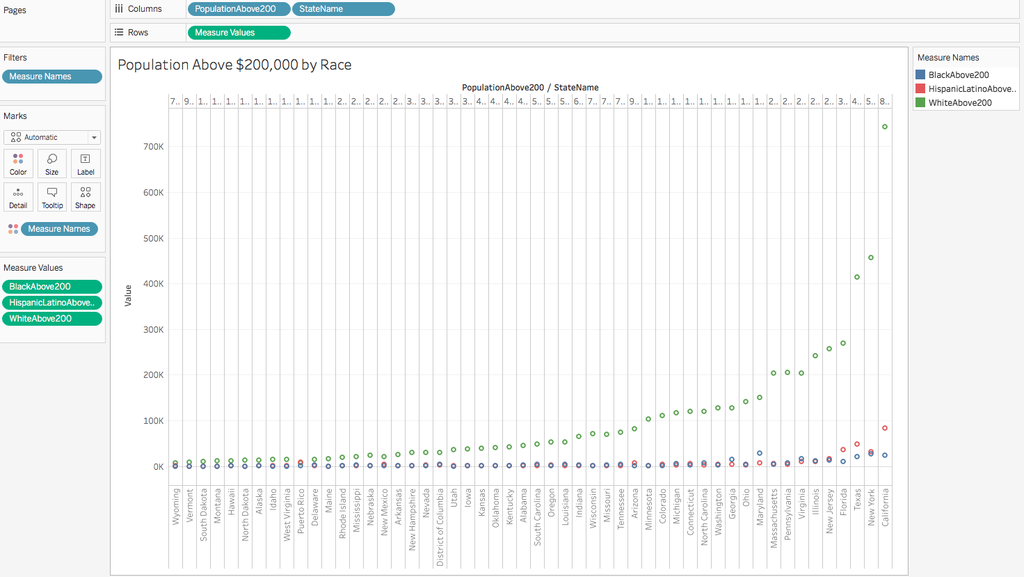

## *Interpretation*

This graph confirms the previous ones, showing a large disparity between white people and black or hispanic people. We see that the more rich people their are, the more the ratio of white people command the group. That contrast is more apparent in some states, especially in California, New York and Texas, but also quite apparent in Florida, New Jersey, Illinois, Virginia, Pennsylvania and Massachussetts.

# **Shiny App**

With this app hosted with Shinyapps, the barcharts for each visualization can be viewed through this link: https://leo16.shinyapps.io/finalproject2/

# **Conclusion**